# Predict Bike Sharing Demand with AutoGluon Template

## Project: Predict Bike Sharing Demand with AutoGluon

This notebook is a template with each step that you need to complete for the project.

Please fill in your code where there are explicit `?` markers in the notebook. You are welcome to add more cells and code as you see fit.

Once you have completed all the code implementations, please export your notebook as a HTML file so the reviews can view your code. Make sure you have all outputs correctly outputted.

`File-> Export Notebook As... -> Export Notebook as HTML`

There is a writeup to complete as well after all code implememtation is done. Please answer all questions and attach the necessary tables and charts. You can complete the writeup in either markdown or PDF.

Completing the code template and writeup template will cover all of the rubric points for this project.

The rubric contains "Stand Out Suggestions" for enhancing the project beyond the minimum requirements. The stand out suggestions are optional. If you decide to pursue the "stand out suggestions", you can include the code in this notebook and also discuss the results in the writeup file.

## Step 1: Create an account with Kaggle

### Create Kaggle Account and download API key

Below is example of steps to get the API username and key. Each student will have their own username and key.

1. Open account settings.

2. Scroll down to API and click Create New API Token.

3. Open up `kaggle.json` and use the username and key.


## Step 2: Download the Kaggle dataset using the kaggle python library

### Install packages

```python
!pip install -U pip
!pip install -U setuptools wheel
!pip install -U "mxnet" bokeh
!pip install autogluon --no-cache-dir
# Without --no-cache-dir, smaller aws instances may have trouble installing
```

[output not shown]

### Setup Kaggle API Key

```python
# create the .kaggle directory and an empty kaggle.json file
!mkdir -p ~/.kaggle
!touch ~/.kaggle/kaggle.json
!chmod 600 ~/.kaggle/kaggle.json
```

```python
# Fill in your user name and key from creating the kaggle account and API token file
import json
import os

kaggle_username = "luluwaa"
kaggle_key = "ed76a1fc3481dcdaa884426dc474e038"

kaggle_json_path = os.path.expanduser("~/.kaggle/kaggle.json")
kaggle_json_path

# Save API token the kaggle.json file
with open(kaggle_json_path, "w") as f:
    f.write(json.dumps({"username": kaggle_username, "key": kaggle_key}))
```

### Download and explore dataset

### Go to the [bike sharing demand competition](https://www.kaggle.com/c/bike-sharing-demand) and agree to the terms

```python
# Download the dataset, it will be in a .zip file so you'll need to unzip it as well.
!kaggle competitions download -c bike-sharing-demand
# If you already downloaded it you can use the -o command to overwrite the file
!unzip -o bike-sharing-demand.zip
```

[output not shown]

```python
import pandas as pd
from autogluon.tabular import TabularPredictor
```

```python
# Create the train dataset in pandas by reading the csv
# Set the parsing of the datetime column so you can use some of the `dt` features in pandas later
train = pd.read_csv("train.csv",parse_dates=["datetime"])
train.head()
```

|  | datetime | season | holiday | workingday | weather | temp | atemp | humidity | windspeed | casual | registered | count |
| --- | --- | --- | --- | --- | --- | --- | --- | --- | --- | --- | --- | --- |
| 0 | 2011-01-01 00:00:00 | 1 | 0 | 0 | 1 | 9.84 | 14.395 | 81 | 0.0 | 3 | 13 | 16 |
| 1 | 2011-01-01 01:00:00 | 1 | 0 | 0 | 1 | 9.02 | 13.635 | 80 | 0.0 | 8 | 32 | 40 |
| 2 | 2011-01-01 02:00:00 | 1 | 0 | 0 | 1 | 9.02 | 13.635 | 80 | 0.0 | 5 | 27 | 32 |
| 3 | 2011-01-01 03:00:00 | 1 | 0 | 0 | 1 | 9.84 | 14.395 | 75 | 0.0 | 3 | 10 | 13 |
| 4 | 2011-01-01 04:00:00 | 1 | 0 | 0 | 1 | 9.84 | 14.395 | 75 | 0.0 | 0 | 1 | 1 |

```python
# Simple output of the train dataset to view some of the min/max/varition of the dataset features.
train.describe()
```

|  | datetime | season | holiday | workingday | weather | temp | atemp | humidity | windspeed | casual | registered | count |
| --- | --- | --- | --- | --- | --- | --- | --- | --- | --- | --- | --- | --- |
| count | 10886 | 10886.000000 | 10886.000000 | 10886.000000 | 10886.000000 | 10886.00000 | 10886.000000 | 10886.000000 | 10886.000000 | 10886.000000 | 10886.000000 | 10886.000000 |
| mean | 2011-12-27 05:56:22.399411968 | 2.506614 | 0.028569 | 0.680875 | 1.418427 | 20.23086 | 23.655084 | 61.886460 | 12.799395 | 36.021955 | 155.552177 | 191.574132 |
| min | 2011-01-01 00:00:00 | 1.000000 | 0.000000 | 0.000000 | 1.000000 | 0.82000 | 0.760000 | 0.000000 | 0.000000 | 0.000000 | 0.000000 | 1.000000 |
| 25% | 2011-07-02 07:15:00 | 2.000000 | 0.000000 | 0.000000 | 1.000000 | 13.94000 | 16.665000 | 47.000000 | 7.001500 | 4.000000 | 36.000000 | 42.000000 |
| 50% | 2012-01-01 20:30:00 | 3.000000 | 0.000000 | 1.000000 | 1.000000 | 20.50000 | 24.240000 | 62.000000 | 12.998000 | 17.000000 | 118.000000 | 145.000000 |
| 75% | 2012-07-01 12:45:00 | 4.000000 | 0.000000 | 1.000000 | 2.000000 | 26.24000 | 31.060000 | 77.000000 | 16.997900 | 49.000000 | 222.000000 | 284.000000 |
| max | 2012-12-19 23:00:00 | 4.000000 | 1.000000 | 1.000000 | 4.000000 | 41.00000 | 45.455000 | 100.000000 | 56.996900 | 367.000000 | 886.000000 | 977.000000 |
| std | NaN | 1.116174 | 0.166599 | 0.466159 | 0.633839 | 7.79159 | 8.474601 | 19.245033 | 8.164537 | 49.960477 | 151.039033 | 181.144454 |

```python
train.info()
```

```
<class 'pandas.core.frame.DataFrame'>
RangeIndex: 10886 entries, 0 to 10885
Data columns (total 12 columns):
 #   Column      Non-Null Count  Dtype
---  ------      --------------  -----
 0   datetime    10886 non-null  datetime64[ns]
 1   season      10886 non-null  int64
 2   holiday     10886 non-null  int64
 3   workingday  10886 non-null  int64
 4   weather     10886 non-null  int64
 5   temp        10886 non-null  float64
 6   atemp       10886 non-null  float64
 7   humidity    10886 non-null  int64
 8   windspeed   10886 non-null  float64
 9   casual      10886 non-null  int64
 10  registered  10886 non-null  int64
 11  count       10886 non-null  int64
dtypes: datetime64[ns](1), float64(3), int64(8)
memory usage: 1020.7 KB
```

```python
print("Column Names:", train.columns)  # Print column names
print("Shape of Train:", train.shape)       # Print shape (rows, columns)
```

```
Column Names: Index(['datetime', 'season', 'holiday', 'workingday', 'weather', 'temp',
       'atemp', 'humidity', 'windspeed', 'casual', 'registered', 'count'],
      dtype='object')
Shape of Train: (10886, 12)
```

```python
# Create the test pandas dataframe in pandas by reading the csv, remember to parse the datetime!
test = pd.read_csv('test.csv',parse_dates = ['datetime'])
test.head()
```

|  | datetime | season | holiday | workingday | weather | temp | atemp | humidity | windspeed |
| --- | --- | --- | --- | --- | --- | --- | --- | --- | --- |
| 0 | 2011-01-20 00:00:00 | 1 | 0 | 1 | 1 | 10.66 | 11.365 | 56 | 26.0027 |
| 1 | 2011-01-20 01:00:00 | 1 | 0 | 1 | 1 | 10.66 | 13.635 | 56 | 0.0000 |
| 2 | 2011-01-20 02:00:00 | 1 | 0 | 1 | 1 | 10.66 | 13.635 | 56 | 0.0000 |
| 3 | 2011-01-20 03:00:00 | 1 | 0 | 1 | 1 | 10.66 | 12.880 | 56 | 11.0014 |
| 4 | 2011-01-20 04:00:00 | 1 | 0 | 1 | 1 | 10.66 | 12.880 | 56 | 11.0014 |

```python
# Check for missing values
print(test.isnull().sum())
```

```
datetime      0
season        0
holiday       0
workingday    0
weather       0
temp          0
atemp         0
humidity      0
windspeed     0
dtype: int64
```

```python
print("Column Names:", test.columns)  # Print column names
print("Shape of Test:", test.shape)       # Print shape (rows, columns)
```

```
Column Names: Index(['datetime', 'season', 'holiday', 'workingday', 'weather', 'temp',
       'atemp', 'humidity', 'windspeed'],
      dtype='object')
Shape of Test: (6493, 9)
```

```python
# Same thing as train and test dataset
submission = pd.read_csv('sampleSubmission.csv',parse_dates = ['datetime'])
submission.head()
```

|  | datetime | count |
| --- | --- | --- |
| 0 | 2011-01-20 00:00:00 | 0 |
| 1 | 2011-01-20 01:00:00 | 0 |
| 2 | 2011-01-20 02:00:00 | 0 |
| 3 | 2011-01-20 03:00:00 | 0 |
| 4 | 2011-01-20 04:00:00 | 0 |

## Step 3: Train a model using AutoGluon’s Tabular Prediction

Requirements:

- We are predicting `count`, so it is the label we are setting.
- Ignore `casual` and `registered` columns as they are also not present in the test dataset.
- Use the `root_mean_squared_error` as the metric to use for evaluation.
- Set a time limit of 10 minutes (600 seconds).
- Use the preset `best_quality` to focus on creating the best model.

```python
predictor = TabularPredictor(label='count',eval_metric = 'root_mean_squared_error',
                             learner_kwargs = {"ignored_columns": ["casual", "registered"]}).fit(
    train_data = train,
    time_limit =600,
    presets = 'best_quality')
```

[output not shown]

[output cut: 103 more lines]

```
	Fitting 8 child models (S1F1 - S1F8) | Fitting with ParallelLocalFoldFittingStrategy (2 workers, per: cpus=1, gpus=0, memory=0.87%)
	-54.92	 = Validation score   (-root_mean_squared_error)
	25.05s	 = Training   runtime
	0.26s	 = Validation runtime
Fitting model: RandomForestMSE_BAG_L2 ... Training model for up to 16.34s of the 16.30s of remaining time.
	-53.4649	 = Validation score   (-root_mean_squared_error)
	39.49s	 = Training   runtime
	0.75s	 = Validation runtime
Fitting model: WeightedEnsemble_L3 ... Training model for up to 360.00s of the -24.64s of remaining time.
	Ensemble Weights: {'RandomForestMSE_BAG_L2': 0.68, 'LightGBM_BAG_L2': 0.28, 'LightGBMXT_BAG_L2': 0.04}
	-53.1044	 = Validation score   (-root_mean_squared_error)
	0.03s	 = Training   runtime
	0.0s	 = Validation runtime
AutoGluon training complete, total runtime = 421.14s ... Best model: WeightedEnsemble_L3 | Estimated inference throughput: 93.9 rows/s (1361 batch size)
TabularPredictor saved. To load, use: predictor = TabularPredictor.load("/home/sagemaker-user/nd009t-c1-intro-to-ml-project-starter/AutogluonModels/ag-20250527_190028")
```

### Review AutoGluon's training run with ranking of models that did the best.

```python
predictor.fit_summary()
```

```
*** Summary of fit() ***
Estimated performance of each model:
                     model   score_val              eval_metric  pred_time_val    fit_time  pred_time_val_marginal  fit_time_marginal  stack_level  can_infer  fit_order
0      WeightedEnsemble_L3  -53.104367  root_mean_squared_error      16.357975  387.168541                0.000658           0.032009            3       True         13
1   RandomForestMSE_BAG_L2  -53.464857  root_mean_squared_error      12.311599  308.391558                0.746324          39.491746            2       True         12
2          LightGBM_BAG_L2  -54.920002  root_mean_squared_error      11.823101  293.948120                0.257826          25.048308            2       True         11
3        LightGBMXT_BAG_L2  -60.505066  root_mean_squared_error      15.353166  322.596479                3.787891          53.696666            2       True         10
4    KNeighborsDist_BAG_L1  -84.125061  root_mean_squared_error       0.070965    0.045091                0.070965           0.045091            1       True          2
5      WeightedEnsemble_L2  -84.125061  root_mean_squared_error       0.071727    0.082351                0.000762           0.037261            2       True          9
6    KNeighborsUnif_BAG_L1 -101.546199  root_mean_squared_error       0.056505    0.054716                0.056505           0.054716            1       True          1
7   RandomForestMSE_BAG_L1 -116.548359  root_mean_squared_error       0.596267   14.649452                0.596267          14.649452            1       True          5
8     ExtraTreesMSE_BAG_L1 -124.600676  root_mean_squared_error       0.666762    6.969487                0.666762           6.969487            1       True          7
9          CatBoost_BAG_L1 -130.749956  root_mean_squared_error       0.138467  125.383478                0.138467         125.383478            1       True          6
10         LightGBM_BAG_L1 -131.054162  root_mean_squared_error       1.605431   28.159685                1.605431          28.159685            1       True          4
11       LightGBMXT_BAG_L1 -131.460909  root_mean_squared_error       8.040825   59.421723                8.040825          59.421723            1       True          3
12  NeuralNetFastAI_BAG_L1 -147.499977  root_mean_squared_error       0.390053   34.216181                0.390053          34.216181            1       True          8
Number of models trained: 13
Types of models trained:
{'StackerEnsembleModel_NNFastAiTabular', 'WeightedEnsembleModel', 'StackerEnsembleModel_CatBoost', 'StackerEnsembleModel_XT', 'StackerEnsembleModel_KNN', 'StackerEnsembleModel_LGB', 'StackerEnsembleModel_RF'}
Bagging used: True  (with 8 folds)
Multi-layer stack-ensembling used: True  (with 3 levels)
Feature Metadata (Processed):
(raw dtype, special dtypes):
('float', [])                : 3 | ['temp', 'atemp', 'windspeed']
('int', [])                  : 3 | ['season', 'weather', 'humidity']
('int', ['bool'])            : 2 | ['holiday', 'workingday']
('int', ['datetime_as_int']) : 5 | ['datetime', 'datetime.year', 'datetime.month', 'datetime.day', 'datetime.dayofweek']
Plot summary of models saved to file: /home/sagemaker-user/nd009t-c1-intro-to-ml-project-starter/AutogluonModels/ag-20250527_190028SummaryOfModels.html
*** End of fit() summary ***
```

[output not shown]

[output cut: 127 more lines]

```

     stack_level  can_infer  fit_order
 0             3       True         13
 1             2       True         12
 2             2       True         11
 3             2       True         10
 4             1       True          2
 5             2       True          9
 6             1       True          1
 7             1       True          5
 8             1       True          7
 9             1       True          6
 10            1       True          4
 11            1       True          3
 12            1       True          8  }
```

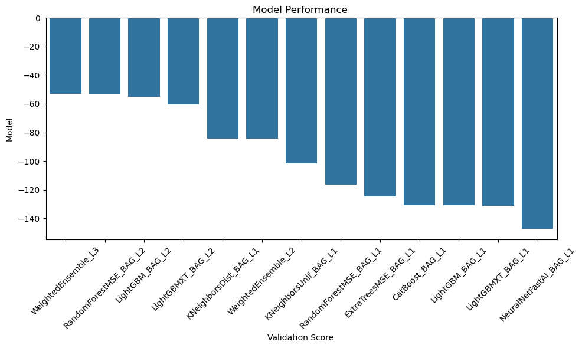

```python
import seaborn as sns
import matplotlib.pyplot as plt

leaderboard_df = predictor.leaderboard(silent=True)

plt.figure(figsize=(10, 6))
sns.barplot(data=leaderboard_df,x='model', y='score_val')
plt.title('Model Performance ')
plt.xlabel('Validation Score ')
plt.ylabel('Model')
plt.xticks(rotation=45)
plt.tight_layout()
plt.show()
```

```python
# Print the list of all model names trained by AutoGluon predictor
print(predictor.model_names())
```

```
['KNeighborsUnif_BAG_L1', 'KNeighborsDist_BAG_L1', 'LightGBMXT_BAG_L1', 'LightGBM_BAG_L1', 'RandomForestMSE_BAG_L1', 'CatBoost_BAG_L1', 'ExtraTreesMSE_BAG_L1', 'NeuralNetFastAI_BAG_L1', 'WeightedEnsemble_L2', 'LightGBMXT_BAG_L2', 'LightGBM_BAG_L2', 'RandomForestMSE_BAG_L2', 'WeightedEnsemble_L3']
```

### Create predictions from test dataset

```python
predictions = predictor.predict(test)
predictions.head()
```

```
0    23.221382
1    41.329277
2    45.402527
3    47.915691
4    50.960381
Name: count, dtype: float32
```

#### NOTE: Kaggle will reject the submission if we don't set everything to be > 0.

```python
# Describe the `predictions` series to see if there are any negative values
predictions.describe()
```

```
count    6493.000000
mean      100.333496
std        89.753250
min         3.144829
25%        19.654394
50%        64.008377
75%       167.854416
max       367.106812
Name: count, dtype: float64
```

```python
# How many negative values do we have?
negative_count = (predictions < 0).sum()
print("Number of negative values :", negative_count)
```

```
Number of negative values : 0
```

```python
# Set them to zero
predictions[predictions<0] = 0
```

### Set predictions to submission dataframe, save, and submit

```python
submission["count"] = predictions
submission.to_csv("submission.csv", index=False)
```

```python
!kaggle competitions submit -c bike-sharing-demand -f submission.csv -m "first raw submission"
```

```
Successfully submitted to Bike Sharing Demand
```

#### View submission via the command line or in the web browser under the competition's page - `My Submissions`

```python
!kaggle competitions submissions -c bike-sharing-demand | tail -n +1 | head -n 6
```

```
fileName                     date                        description                        status                     publicScore  privateScore
---------------------------  --------------------------  ---------------------------------  -------------------------  -----------  ------------
submission.csv               2025-05-27 19:31:42.897000  first raw submission               SubmissionStatus.COMPLETE  1.80160      1.80160
submission.csv               2025-05-27 16:49:01.910000  first raw submission               SubmissionStatus.COMPLETE  1.79767      1.79767
submission_new_hpo.csv       2025-05-27 14:31:35.040000  new features with hyperparameters  SubmissionStatus.COMPLETE  2.21852      2.21852
submission_new_features.csv  2025-05-27 12:55:32.283000  new features                       SubmissionStatus.COMPLETE  0.61693      0.61693
```

#### Initial score of `1.801`

## Step 4: Exploratory Data Analysis and Creating an additional feature

- Any additional feature will do, but a great suggestion would be to separate out the datetime into hour, day, or month parts.

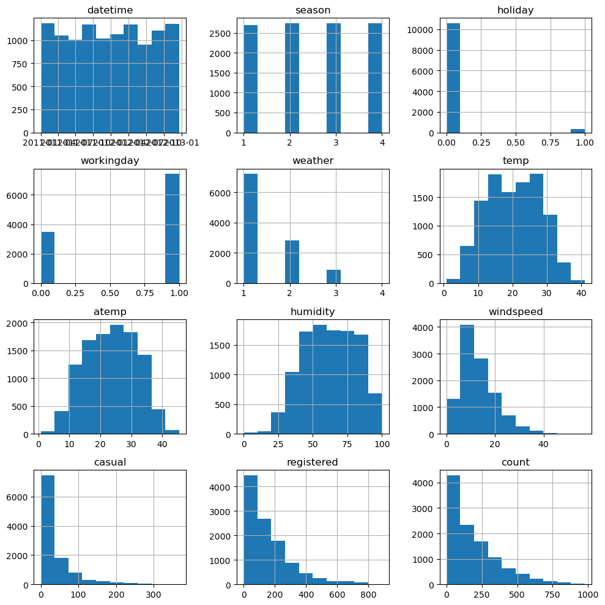

```python
# Create a histogram of all features to show the distribution of each one relative to the data. This is part of the exploritory data analysis
train.hist(figsize = [10,10])
plt.tight_layout()
plt.show()
```

```python
# create a new feature
train["year"] = train["datetime"].dt.year
train['month']= train['datetime'].dt.month
train['day']  = train['datetime'].dt.day
train["hour"] = train["datetime"].dt.hour

test["year"] = test["datetime"].dt.year
test['month'] = test['datetime'].dt.month
test['day'] = test['datetime'].dt.day
test["hour"] = test["datetime"].dt.hour
```

## Make category types for these so models know they are not just numbers

- AutoGluon originally sees these as ints, but in reality they are int representations of a category.
- Setting the dtype to category will classify these as categories in AutoGluon.

```python
train["season"] = train["season"].astype('category')
train["weather"] = train["weather"].astype('category')
test["season"] = test["season"].astype('category')
test["weather"] = test["weather"].astype('category')
```

```python
# View are new feature
train.head()
```

|  | datetime | season | holiday | workingday | weather | temp | atemp | humidity | windspeed | casual | registered | count | year | month | day | hour |
| --- | --- | --- | --- | --- | --- | --- | --- | --- | --- | --- | --- | --- | --- | --- | --- | --- |
| 0 | 2011-01-01 00:00:00 | 1 | 0 | 0 | 1 | 9.84 | 14.395 | 81 | 0.0 | 3 | 13 | 16 | 2011 | 1 | 1 | 0 |
| 1 | 2011-01-01 01:00:00 | 1 | 0 | 0 | 1 | 9.02 | 13.635 | 80 | 0.0 | 8 | 32 | 40 | 2011 | 1 | 1 | 1 |
| 2 | 2011-01-01 02:00:00 | 1 | 0 | 0 | 1 | 9.02 | 13.635 | 80 | 0.0 | 5 | 27 | 32 | 2011 | 1 | 1 | 2 |
| 3 | 2011-01-01 03:00:00 | 1 | 0 | 0 | 1 | 9.84 | 14.395 | 75 | 0.0 | 3 | 10 | 13 | 2011 | 1 | 1 | 3 |
| 4 | 2011-01-01 04:00:00 | 1 | 0 | 0 | 1 | 9.84 | 14.395 | 75 | 0.0 | 0 | 1 | 1 | 2011 | 1 | 1 | 4 |

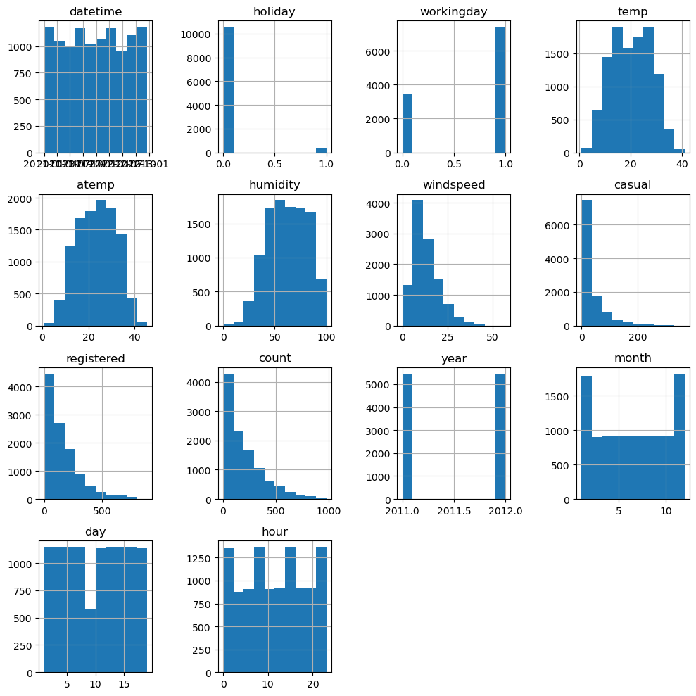

```python
# View histogram of all features again now with the hour feature
train.hist(figsize = [10,10])
plt.tight_layout()
plt.show()
```

## Step 5: Rerun the model with the same settings as before, just with more features

```python
predictor_new_features = TabularPredictor(label = 'count',eval_metric = 'root_mean_squared_error',learner_kwargs =
                                          {"ignored_columns": ["casual", "registered"]}).fit(train_data=train,
                                                                                             time_limit =600,
                                                                                             presets = 'best_quality')
```

[output not shown]

[output cut: 117 more lines]

```
	14.07s	 = Training   runtime
	0.21s	 = Validation runtime
Fitting model: CatBoost_BAG_L2 ... Training model for up to 45.51s of the 45.46s of remaining time.
	Fitting 8 child models (S1F1 - S1F8) | Fitting with ParallelLocalFoldFittingStrategy (2 workers, per: cpus=1, gpus=0, memory=1.76%)
I0000 00:00:1748375264.257569    1444 chttp2_transport.cc:1182] ipv4:169.255.255.2:43643: Got goaway [2] err=UNAVAILABLE:GOAWAY received; Error code: 2; Debug Text: Cancelling all calls {created_time:"2025-05-27T19:47:44.257564739+00:00", http2_error:2, grpc_status:14}
	-31.0138	 = Validation score   (-root_mean_squared_error)
	47.63s	 = Training   runtime
	0.14s	 = Validation runtime
Fitting model: WeightedEnsemble_L3 ... Training model for up to 360.00s of the -5.72s of remaining time.
	Ensemble Weights: {'CatBoost_BAG_L2': 0.727, 'RandomForestMSE_BAG_L2': 0.273}
	-30.8466	 = Validation score   (-root_mean_squared_error)
	0.05s	 = Training   runtime
	0.0s	 = Validation runtime
AutoGluon training complete, total runtime = 432.16s ... Best model: WeightedEnsemble_L3 | Estimated inference throughput: 81.9 rows/s (1361 batch size)
TabularPredictor saved. To load, use: predictor = TabularPredictor.load("/home/sagemaker-user/nd009t-c1-intro-to-ml-project-starter/AutogluonModels/ag-20250527_193738")
```

```python
predictor_new_features.fit_summary()
```

```
*** Summary of fit() ***
Estimated performance of each model:
                     model   score_val              eval_metric  pred_time_val    fit_time  pred_time_val_marginal  fit_time_marginal  stack_level  can_infer  fit_order
0      WeightedEnsemble_L3  -30.846648  root_mean_squared_error      17.388834  362.814828                0.000815           0.052459            3       True         14
1          CatBoost_BAG_L2  -31.013841  root_mean_squared_error      17.182071  348.691117                0.140172          47.633636            2       True         13
2   RandomForestMSE_BAG_L2  -31.997147  root_mean_squared_error      17.247847  315.128734                0.205948          14.071253            2       True         12
3      WeightedEnsemble_L2  -32.785446  root_mean_squared_error       3.526169  180.659859                0.000798           0.042219            2       True          9
4          LightGBM_BAG_L1  -33.917339  root_mean_squared_error       3.020483   40.343348                3.020483          40.343348            1       True          4
5          CatBoost_BAG_L1  -34.615724  root_mean_squared_error       0.148967  133.134607                0.148967         133.134607            1       True          6
6   RandomForestMSE_BAG_L1  -38.801642  root_mean_squared_error       0.290736    7.098777                0.290736           7.098777            1       True          5
7     ExtraTreesMSE_BAG_L1  -39.610916  root_mean_squared_error       0.273091    2.346493                0.273091           2.346493            1       True          7
8        LightGBMXT_BAG_L1  -68.869862  root_mean_squared_error      12.773971   74.466714               12.773971          74.466714            1       True          3
9    KNeighborsDist_BAG_L1  -84.125061  root_mean_squared_error       0.065185    0.040908                0.065185           0.040908            1       True          2
10   KNeighborsUnif_BAG_L1 -101.546199  root_mean_squared_error       0.056224    0.039289                0.056224           0.039289            1       True          1
11  NeuralNetFastAI_BAG_L1 -108.808708  root_mean_squared_error       0.413243   43.587345                0.413243          43.587345            1       True          8
12       LightGBMXT_BAG_L2 -152.147389  root_mean_squared_error      17.098993  319.221265                0.057094          18.163784            2       True         10
13         LightGBM_BAG_L2 -155.410842  root_mean_squared_error      17.077939  319.274400                0.036039          18.216919            2       True         11
Number of models trained: 14
Types of models trained:
{'StackerEnsembleModel_NNFastAiTabular', 'WeightedEnsembleModel', 'StackerEnsembleModel_CatBoost', 'StackerEnsembleModel_XT', 'StackerEnsembleModel_KNN', 'StackerEnsembleModel_LGB', 'StackerEnsembleModel_RF'}
Bagging used: True  (with 8 folds)
Multi-layer stack-ensembling used: True  (with 3 levels)
Feature Metadata (Processed):
(raw dtype, special dtypes):
('category', [])             : 2 | ['season', 'weather']
('float', [])                : 3 | ['temp', 'atemp', 'windspeed']
('int', [])                  : 4 | ['humidity', 'month', 'day', 'hour']
('int', ['bool'])            : 3 | ['holiday', 'workingday', 'year']
('int', ['datetime_as_int']) : 3 | ['datetime', 'datetime.year', 'datetime.dayofweek']
Plot summary of models saved to file: /home/sagemaker-user/nd009t-c1-intro-to-ml-project-starter/AutogluonModels/ag-20250527_193738SummaryOfModels.html
*** End of fit() summary ***
```

[output not shown]

[output cut: 140 more lines]

```
     stack_level  can_infer  fit_order
 0             3       True         14
 1             2       True         13
 2             2       True         12
 3             2       True          9
 4             1       True          4
 5             1       True          6
 6             1       True          5
 7             1       True          7
 8             1       True          3
 9             1       True          2
 10            1       True          1
 11            1       True          8
 12            2       True         10
 13            2       True         11  }
```

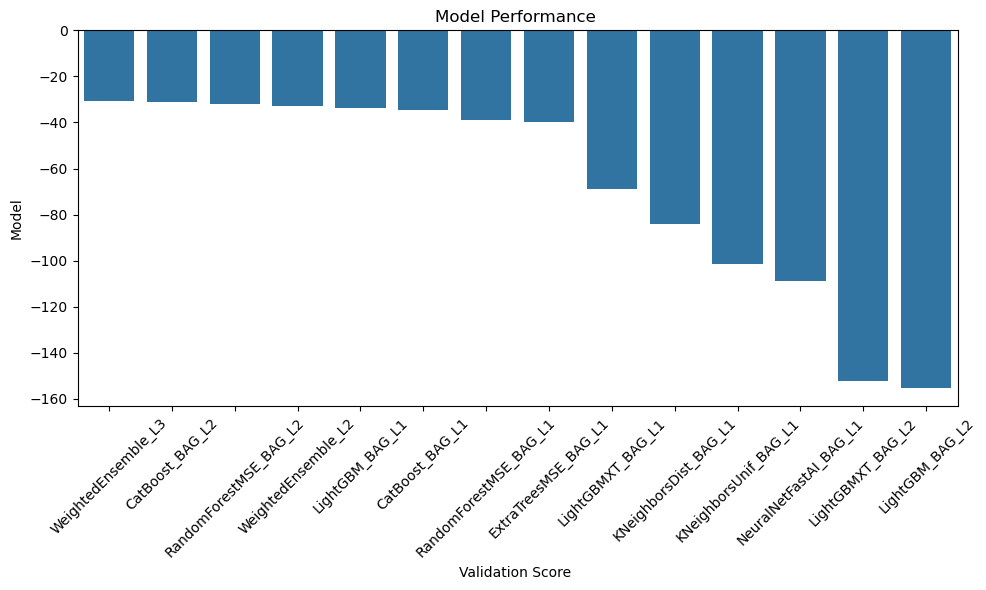

```python
leaderboard_df = predictor_new_features.leaderboard(silent=True)

plt.figure(figsize=(10, 6))
sns.barplot(data=leaderboard_df,x='model', y='score_val')
plt.title('Model Performance ')
plt.xlabel('Validation Score ')
plt.ylabel('Model')
plt.xticks(rotation=45)
plt.tight_layout()
plt.show()
```

```python
# Print the list of all model names trained by AutoGluon predictor
print(predictor_new_features.model_names())
```

```
['KNeighborsUnif_BAG_L1', 'KNeighborsDist_BAG_L1', 'LightGBMXT_BAG_L1', 'LightGBM_BAG_L1', 'RandomForestMSE_BAG_L1', 'CatBoost_BAG_L1', 'ExtraTreesMSE_BAG_L1', 'NeuralNetFastAI_BAG_L1', 'WeightedEnsemble_L2', 'LightGBMXT_BAG_L2', 'LightGBM_BAG_L2', 'RandomForestMSE_BAG_L2', 'CatBoost_BAG_L2', 'Weigh…
```

```python
predictor_2_features = predictor_new_features.predict(test)
predictor_2_features.head()
```

```
0    15.464817
1    10.720163
2     9.302755
3     8.021637
4     6.641370
Name: count, dtype: float32
```

```python
# Remember to set all negative values to zero
negative_count = (predictor_2_features < 0).sum()
print("Number of negative values :", negative_count)
```

```
Number of negative values : 0
```

```python
predictor_2_features[predictor_2_features<0] = 0
```

```python
# Same submitting predictions
submission_new_features = pd.read_csv('sampleSubmission.csv', parse_dates = ['datetime'])

submission_new_features["count"] = predictor_2_features
submission_new_features.to_csv("submission_new_features.csv", index=False)
```

```python
!kaggle competitions submit -c bike-sharing-demand -f submission_new_features.csv -m "new features"
```

```
Successfully submitted to Bike Sharing Demand
```

```python
!kaggle competitions submissions -c bike-sharing-demand | tail -n +1 | head -n 6
```

```
fileName                     date                        description                        status                     publicScore  privateScore
---------------------------  --------------------------  ---------------------------------  -------------------------  -----------  ------------
submission_new_features.csv  2025-05-27 19:59:22.623000  new features                       SubmissionStatus.COMPLETE  0.67011      0.67011
submission.csv               2025-05-27 19:31:42.897000  first raw submission               SubmissionStatus.COMPLETE  1.80160      1.80160
submission.csv               2025-05-27 16:49:01.910000  first raw submission               SubmissionStatus.COMPLETE  1.79767      1.79767
submission_new_hpo.csv       2025-05-27 14:31:35.040000  new features with hyperparameters  SubmissionStatus.COMPLETE  2.21852      2.21852
```

#### New Score of `0.670`

## Step 6: Hyper parameter optimization

- There are many options for hyper parameter optimization.
- Options are to change the AutoGluon higher level parameters or the individual model hyperparameters.
- The hyperparameters of the models themselves that are in AutoGluon. Those need the `hyperparameter` and `hyperparameter_tune_kwargs` arguments.

```python
from autogluon.common import space
from autogluon.tabular import TabularPredictor

hpo_settings = {
    'num_trials': 20,
    'searcher': 'random',
    'scheduler': 'local'
}

model_hyperparameters = {
    'GBM': {
        'learning_rate': space.Real(0.01, 0.2),
        'max_depth': space.Int(3, 10),
    },
    'CAT': {
        'learning_rate': space.Real(0.01, 0.15),
        'depth': space.Int(4, 8),
    },
    'XGB': {
        'learning_rate': space.Real(0.01, 0.2),
        'max_depth': space.Int(3, 8),
    },
    'RF': {},
}

predictor_new_hpo = TabularPredictor(
    label='count',
    eval_metric='root_mean_squared_error',
    problem_type='regression',
    learner_kwargs={"ignored_columns": ["casual", "registered"]}
).fit(
    train_data=train,
    time_limit=400,
    presets='best_quality',
    hyperparameter_tune_kwargs=hpo_settings,
    hyperparameters=model_hyperparameters,
    dynamic_stacking=False
)
```

[output not shown]

[output cut: 17 more lines]

```
	Train Data (Processed) Memory Usage: 0.76 MB (0.1% of available memory)
Data preprocessing and feature engineering runtime = 0.64s ...
AutoGluon will gauge predictive performance using evaluation metric: 'root_mean_squared_error'
	This metric's sign has been flipped to adhere to being higher_is_better. The metric score can be multiplied by -1 to get the metric value.
	To change this, specify the eval_metric parameter of Predictor()
User-specified model hyperparameters to be fit:
{
	'GBM': [{'learning_rate': Real: lower=0.01, upper=0.2, 'max_depth': Int: lower=3, upper=10}],
	'CAT': [{'learning_rate': Real: lower=0.01, upper=0.15, 'depth': Int: lower=4, upper=8}],
	'XGB': [{'learning_rate': Real: lower=0.01, upper=0.2, 'max_depth': Int: lower=3, upper=8}],
	'RF': [{}],
}
AutoGluon will fit 2 stack levels (L1 to L2) ...
Fitting 4 L1 models, fit_strategy="sequential" ...
Hyperparameter tuning model: LightGBM_BAG_L1 ... Tuning model for up to 59.89s of the 399.36s of remaining time.
```

```
	Fitting 8 child models (S1F1 - S1F8) | Fitting with ParallelLocalFoldFittingStrategy (2 workers, per: cpus=1, gpus=0, memory=1.00%)
	Fitting 8 child models (S1F1 - S1F8) | Fitting with ParallelLocalFoldFittingStrategy (2 workers, per: cpus=1, gpus=0, memory=1.87%)
I0000 00:00:1748377362.767614    1445 chttp2_transport.cc:1182] ipv4:169.255.255.2:35247: Got goaway [2] err=UNAVAILABLE:GOAWAY received; Error code: 2; Debug Text: Cancelling all calls {created_time:"2025-05-27T20:22:42.765116076+00:00", http2_error:2, grpc_status:14}
	Stopping HPO to satisfy time limit...
Fitted model: LightGBM_BAG_L1/T1 ...
	-180.1767	 = Validation score   (-root_mean_squared_error)
	22.75s	 = Training   runtime
	0.02s	 = Validation runtime
Fitted model: LightGBM_BAG_L1/T2 ...
	-162.5885	 = Validation score   (-root_mean_squared_error)
	27.06s	 = Training   runtime
	0.05s	 = Validation runtime
Hyperparameter tuning model: RandomForest_BAG_L1 ... Tuning model for up to 59.89s of the 349.46s of remaining time.
	No hyperparameter search space specified for RandomForest_BAG_L1. Skipping HPO. Will train one model based on the provided hyperparameters.
	Warning: Reducing model 'n_estimators' from 300 -> 63 due to low memory. Expected memory usage reduced from 70.56% -> 15.0% of available memory...
Fitted model: RandomForest_BAG_L1 ...
	-39.3776	 = Validation score   (-root_mean_squared_error)
	4.19s	 = Training   runtime
	0.19s	 = Validation runtime
Hyperparameter tuning model: CatBoost_BAG_L1 ... Tuning model for up to 59.89s of the 345.22s of remaining time.
```

```
	Fitting 8 child models (S1F1 - S1F8) | Fitting with ParallelLocalFoldFittingStrategy (2 workers, per: cpus=1, gpus=0, memory=1.70%)
	Stopping HPO to satisfy time limit...
Fitted model: CatBoost_BAG_L1/T1 ...
	-57.3198	 = Validation score   (-root_mean_squared_error)
	60.9s	 = Training   runtime
	0.08s	 = Validation runtime
Hyperparameter tuning model: XGBoost_BAG_L1 ... Tuning model for up to 59.89s of the 284.27s of remaining time.
```

[output not shown]

```
	Fitting 8 child models (S1F1 - S1F8) | Fitting with ParallelLocalFoldFittingStrategy (2 workers, per: cpus=1, gpus=0, memory=2.42%)
I0000 00:00:1748377510.643303    1359 chttp2_transport.cc:1182] ipv4:169.255.255.2:42929: Got goaway [2] err=UNAVAILABLE:GOAWAY received; Error code: 2; Debug Text: Cancelling all calls {created_time:"2025-05-27T20:25:10.64150171+00:00", http2_error:2, grpc_status:14}
	Fitting 8 child models (S1F1 - S1F8) | Fitting with ParallelLocalFoldFittingStrategy (2 workers, per: cpus=1, gpus=0, memory=2.74%)
I0000 00:00:1748377518.210889    1438 chttp2_transport.cc:1182] ipv4:169.255.255.2:40045: Got goaway [2] err=UNAVAILABLE:GOAWAY received; Error code: 2; Debug Text: Cancelling all calls {grpc_status:14, http2_error:2, created_time:"2025-05-27T20:25:18.210883217+00:00"}
	Stopping HPO to satisfy time limit...
Fitted model: LightGBM_BAG_L2/T1 ...
	-179.4573	 = Validation score   (-root_mean_squared_error)
	24.73s	 = Training   runtime
	0.05s	 = Validation runtime
Fitted model: LightGBM_BAG_L2/T2 ...
	-156.1406	 = Validation score   (-root_mean_squared_error)
	24.67s	 = Training   runtime
	0.03s	 = Validation runtime
Hyperparameter tuning model: RandomForest_BAG_L2 ... Tuning model for up to 52.25s of the 182.73s of remaining time.
	No hyperparameter search space specified for RandomForest_BAG_L2. Skipping HPO. Will train one model based on the provided hyperparameters.
	Warning: Reducing model 'n_estimators' from 300 -> 62 due to low memory. Expected memory usage reduced from 71.92% -> 15.0% of available memory...
Fitted model: RandomForest_BAG_L2 ...
	-40.3315	 = Validation score   (-root_mean_squared_error)
	7.86s	 = Training   runtime
	0.24s	 = Validation runtime
Hyperparameter tuning model: CatBoost_BAG_L2 ... Tuning model for up to 52.25s of the 174.82s of remaining time.
```

```
	Fitting 8 child models (S1F1 - S1F8) | Fitting with ParallelLocalFoldFittingStrategy (2 workers, per: cpus=1, gpus=0, memory=2.49%)
I0000 00:00:1748377598.932933    1223 chttp2_transport.cc:1182] ipv4:169.255.255.2:35623: Got goaway [2] err=UNAVAILABLE:GOAWAY received; Error code: 2; Debug Text: Cancelling all calls {grpc_status:14, http2_error:2, created_time:"2025-05-27T20:26:38.931776408+00:00"}
	Stopping HPO to satisfy time limit...
Fitted model: CatBoost_BAG_L2/T1 ...
	-38.6342	 = Validation score   (-root_mean_squared_error)
	55.62s	 = Training   runtime
	0.15s	 = Validation runtime
Hyperparameter tuning model: XGBoost_BAG_L2 ... Tuning model for up to 52.25s of the 119.12s of remaining time.
```

```
	Fitting 8 child models (S1F1 - S1F8) | Fitting with ParallelLocalFoldFittingStrategy (2 workers, per: cpus=1, gpus=0, memory=4.71%)
	Fitting 8 child models (S1F1 - S1F8) | Fitting with ParallelLocalFoldFittingStrategy (2 workers, per: cpus=1, gpus=0, memory=4.12%)
	Stopping HPO to satisfy time limit...
Fitted model: XGBoost_BAG_L2/T1 ...
	-179.4624	 = Validation score   (-root_mean_squared_error)
	18.96s	 = Training   runtime
	0.11s	 = Validation runtime
Fitted model: XGBoost_BAG_L2/T2 ...
	-157.9903	 = Validation score   (-root_mean_squared_error)
	17.05s	 = Training   runtime
	0.13s	 = Validation runtime
Fitting model: WeightedEnsemble_L3 ... Training model for up to 360.00s of the 82.97s of remaining time.
	Ensemble Weights: {'CatBoost_BAG_L2/T1': 0.619, 'RandomForest_BAG_L1': 0.19, 'RandomForest_BAG_L2': 0.19}
	-38.3868	 = Validation score   (-root_mean_squared_error)
	0.04s	 = Training   runtime
	0.0s	 = Validation runtime
AutoGluon training complete, total runtime = 317.15s ... Best model: WeightedEnsemble_L3 | Estimated inference throughput: 2236.2 rows/s (1361 batch size)
TabularPredictor saved. To load, use: predictor = TabularPredictor.load("/home/sagemaker-user/nd009t-c1-intro-to-ml-project-starter/AutogluonModels/ag-20250527_202158")
```

```python
predictor_new_hpo.fit_summary()
```

```
*** Summary of fit() ***
Estimated performance of each model:
                  model   score_val              eval_metric  pred_time_val    fit_time  pred_time_val_marginal  fit_time_marginal  stack_level  can_infer  fit_order
0   WeightedEnsemble_L3  -38.386847  root_mean_squared_error       0.981402  230.182369                0.000793           0.038248            3       True         15
1    CatBoost_BAG_L2/T1  -38.634230  root_mean_squared_error       0.742983  222.288553                0.145382          55.618286            2       True         12
2   WeightedEnsemble_L2  -39.060218  root_mean_squared_error       0.263877   65.125854                0.000791           0.040521            2       True          8
3   RandomForest_BAG_L1  -39.377614  root_mean_squared_error       0.187622    4.190259                0.187622           4.190259            1       True          3
4   RandomForest_BAG_L2  -40.331513  root_mean_squared_error       0.835226  174.525835                0.237626           7.855568            2       True         11
5    CatBoost_BAG_L1/T1  -57.319834  root_mean_squared_error       0.075465   60.895074                0.075465          60.895074            1       True          4
6    LightGBM_BAG_L2/T2 -156.140557  root_mean_squared_error       0.629834  191.339132                0.032234          24.668865            2       True         10
7     XGBoost_BAG_L2/T2 -157.990270  root_mean_squared_error       0.725295  183.722207                0.127695          17.051940            2       True         14
8     XGBoost_BAG_L1/T2 -161.750227  root_mean_squared_error       0.074810   16.530632                0.074810          16.530632            1       True          6
9    LightGBM_BAG_L1/T2 -162.588501  root_mean_squared_error       0.048546   27.062387                0.048546          27.062387            1       True          2
10    XGBoost_BAG_L1/T3 -167.073979  root_mean_squared_error       0.105746   16.651804                0.105746          16.651804            1       True          7
11   LightGBM_BAG_L2/T1 -179.457316  root_mean_squared_error       0.650224  191.398153                0.052624          24.727886            2       True          9
12    XGBoost_BAG_L2/T1 -179.462386  root_mean_squared_error       0.704759  185.627792                0.107159          18.957525            2       True         13
13   LightGBM_BAG_L1/T1 -180.176700  root_mean_squared_error       0.022647   22.754864                0.022647          22.754864            1       True          1
14    XGBoost_BAG_L1/T1 -180.178696  root_mean_squared_error       0.082765   18.585248                0.082765          18.585248            1       True          5
Number of models trained: 15
Types of models trained:
{'WeightedEnsembleModel', 'StackerEnsembleModel_CatBoost', 'StackerEnsembleModel_XGBoost', 'StackerEnsembleModel_LGB', 'StackerEnsembleModel_RF'}
Bagging used: True  (with 8 folds)
Multi-layer stack-ensembling used: True  (with 3 levels)
Feature Metadata (Processed):
(raw dtype, special dtypes):
('category', [])             : 2 | ['season', 'weather']
('float', [])                : 3 | ['temp', 'atemp', 'windspeed']
('int', [])                  : 4 | ['humidity', 'month', 'day', 'hour']
('int', ['bool'])            : 3 | ['holiday', 'workingday', 'year']
('int', ['datetime_as_int']) : 3 | ['datetime', 'datetime.year', 'datetime.dayofweek']
Plot summary of models saved to file: /home/sagemaker-user/nd009t-c1-intro-to-ml-project-starter/AutogluonModels/ag-20250527_202158SummaryOfModels.html
*** End of fit() summary ***
```

[output not shown]

[output cut: 150 more lines]

```
 0        True         15
 1        True         12
 2        True          8
 3        True          3
 4        True         11
 5        True          4
 6        True         10
 7        True         14
 8        True          6
 9        True          2
 10       True          7
 11       True          9
 12       True         13
 13       True          1
 14       True          5  }
```

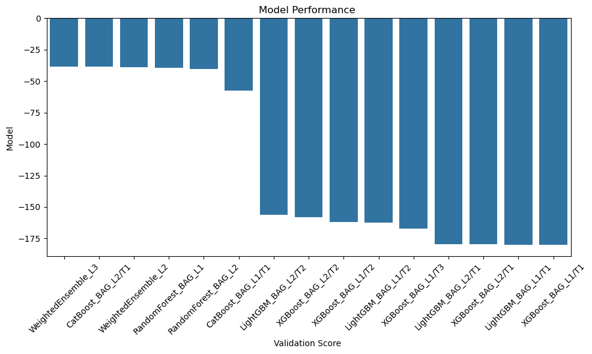

```python
leaderboard_df = predictor_new_hpo.leaderboard(silent=True)

plt.figure(figsize=(10, 6))
sns.barplot(data=leaderboard_df,x='model', y='score_val')
plt.title('Model Performance ')
plt.xlabel('Validation Score ')
plt.ylabel('Model')
plt.xticks(rotation=45)
plt.tight_layout()
plt.show()
```

```python
# Print the list of all model names trained by AutoGluon predictor
print(predictor_new_hpo.model_names())
```

```
['LightGBM_BAG_L1/T1', 'LightGBM_BAG_L1/T2', 'RandomForest_BAG_L1', 'CatBoost_BAG_L1/T1', 'XGBoost_BAG_L1/T1', 'XGBoost_BAG_L1/T2', 'XGBoost_BAG_L1/T3', 'WeightedEnsemble_L2', 'LightGBM_BAG_L2/T1', 'LightGBM_BAG_L2/T2', 'RandomForest_BAG_L2', 'CatBoost_BAG_L2/T1', 'XGBoost_BAG_L2/T1', 'XGBoost_BAG_L…
```

```python
predictor_2_hpo = predictor_new_hpo.predict(test)
predictor_2_hpo.head()
```

```
0    14.054926
1     7.899297
2     6.759377
3     6.340279
4     6.312825
Name: count, dtype: float32
```

```python
# Remember to set all negative values to zero
negative_count = (predictor_2_features < 0).sum()
print("Number of negative values :", negative_count)
predictor_2_features[predictor_2_features<0] = 0
```

```
Number of negative values : 0
```

```python
submission_new_hpo = pd.read_csv('sampleSubmission.csv', parse_dates = ['datetime'])
submission_new_hpo.head()
```

|  | datetime | count |
| --- | --- | --- |
| 0 | 2011-01-20 00:00:00 | 0 |
| 1 | 2011-01-20 01:00:00 | 0 |
| 2 | 2011-01-20 02:00:00 | 0 |
| 3 | 2011-01-20 03:00:00 | 0 |
| 4 | 2011-01-20 04:00:00 | 0 |

```python
# Same submitting predictions
submission_new_hpo["count"] = predictor_2_hpo
submission_new_hpo.to_csv("submission_new_hpo.csv", index=False)
```

```python
!kaggle competitions submit -c bike-sharing-demand -f submission_new_hpo.csv -m "new features with hyperparameters"
```

```
Successfully submitted to Bike Sharing Demand
```

```python
!kaggle competitions submissions -c bike-sharing-demand | tail -n +1 | head -n 6
```

```
fileName                     date                        description                        status                     publicScore  privateScore
---------------------------  --------------------------  ---------------------------------  -------------------------  -----------  ------------
submission_new_hpo.csv       2025-05-27 20:28:50.380000  new features with hyperparameters  SubmissionStatus.COMPLETE  0.49360      0.49360
submission_new_features.csv  2025-05-27 19:59:22.623000  new features                       SubmissionStatus.COMPLETE  0.67011      0.67011
submission.csv               2025-05-27 19:31:42.897000  first raw submission               SubmissionStatus.COMPLETE  1.80160      1.80160
submission.csv               2025-05-27 16:49:01.910000  first raw submission               SubmissionStatus.COMPLETE  1.79767      1.79767
```